# Grupowanie Kmeans & DBSCAN - zadanie zaliczeniowe

Adam Kacprzycki - studia podyplomowe DS - PW Data mining - ed.11 (21L)- grupa I

Intro-step: Import wykorzystywanych bibliotek:

```r
library(tidyverse)
library(dbscan)
library(fpc)
library(cluster)
library(factoextra)
library(gridExtra)
```

Wczytanie danych:

```r
#download.file('http://staff.ii.pw.edu.pl/~rbembeni/dane/Pokemon.csv','Pokemon.csv')
pokemon <- read.csv("Pokemon.csv")
```

**1. Sprawdzenie, jakiego typu są atrybuty, czy są wartości brakujące**

1. Przegląd atrybutów i ich typów danych:

```r
str(pokemon)
```

```
## 'data.frame':    800 obs. of  13 variables:
##  $ X.        : int  1 2 3 3 4 5 6 6 6 7 ...
##  $ Name      : Factor w/ 800 levels "Abomasnow","AbomasnowMega Abomasnow",..: 81 330 746 747 103 104 100 101 102 666 ...
##  $ Type.1    : Factor w/ 18 levels "Bug","Dark","Dragon",..: 10 10 10 10 7 7 7 7 7 18 ...
##  $ Type.2    : Factor w/ 19 levels "","Bug","Dark",..: 15 15 15 15 1 1 9 4 9 1 ...
##  $ Total     : int  318 405 525 625 309 405 534 634 634 314 ...
##  $ HP        : int  45 60 80 80 39 58 78 78 78 44 ...
##  $ Attack    : int  49 62 82 100 52 64 84 130 104 48 ...
##  $ Defense   : int  49 63 83 123 43 58 78 111 78 65 ...
##  $ Sp..Atk   : int  65 80 100 122 60 80 109 130 159 50 ...
##  $ Sp..Def   : int  65 80 100 120 50 65 85 85 115 64 ...
##  $ Speed     : int  45 60 80 80 65 80 100 100 100 43 ...
##  $ Generation: int  1 1 1 1 1 1 1 1 1 1 ...
##  $ Legendary : Factor w/ 2 levels "False","True": 1 1 1 1 1 1 1 1 1 1 ...
```

2. Weryfikacja nie uzupełnionych komórek tj. NA oraz uzupełnionych pustych komórek "":

-funkcja summary - przegląd podstawowych statystyk oraz sprawdzenie wartości brakujących:

```r
summary(pokemon)
```

```
##        X.                             Name         Type.1         Type.2
##  Min.   :  1.0   Abomasnow              :  1   Water  :112           :386
##  1st Qu.:184.8   AbomasnowMega Abomasnow:  1   Normal : 98   Flying  : 97
##  Median :364.5   Abra                   :  1   Grass  : 70   Ground  : 35
##  Mean   :362.8   Absol                  :  1   Bug    : 69   Poison  : 34
##  3rd Qu.:539.2   AbsolMega Absol        :  1   Psychic: 57   Psychic : 33
##  Max.   :721.0   Accelgor               :  1   Fire   : 52   Fighting: 26
##                  (Other)                :794   (Other):342   (Other) :189
##      Total             HP             Attack       Defense
##  Min.   :180.0   Min.   :  1.00   Min.   :  5   Min.   :  5.00
##  1st Qu.:330.0   1st Qu.: 50.00   1st Qu.: 55   1st Qu.: 50.00
##  Median :450.0   Median : 65.00   Median : 75   Median : 70.00
##  Mean   :435.1   Mean   : 69.26   Mean   : 79   Mean   : 73.84
##  3rd Qu.:515.0   3rd Qu.: 80.00   3rd Qu.:100   3rd Qu.: 90.00
##  Max.   :780.0   Max.   :255.00   Max.   :190   Max.   :230.00
##
##     Sp..Atk          Sp..Def          Speed          Generation    Legendary
##  Min.   : 10.00   Min.   : 20.0   Min.   :  5.00   Min.   :1.000   False:735
##  1st Qu.: 49.75   1st Qu.: 50.0   1st Qu.: 45.00   1st Qu.:2.000   True : 65
##  Median : 65.00   Median : 70.0   Median : 65.00   Median :3.000
##  Mean   : 72.82   Mean   : 71.9   Mean   : 68.28   Mean   :3.324
##  3rd Qu.: 95.00   3rd Qu.: 90.0   3rd Qu.: 90.00   3rd Qu.:5.000
##  Max.   :194.00   Max.   :230.0   Max.   :180.00   Max.   :6.000
##
```

- dodatkowa weryfikacja wartości NA:

```r
colSums(is.na(pokemon))
```

```
##         X.       Name     Type.1     Type.2      Total         HP     Attack
##          0          0          0          0          0          0          0
##    Defense    Sp..Atk    Sp..Def      Speed Generation  Legendary
##          0          0          0          0          0          0
```

- weryfikacja “pustych” komórek:

```r
colSums(pokemon == "")
```

```
##         X.       Name     Type.1     Type.2      Total         HP     Attack
##          0          0          0        386          0          0          0
##    Defense    Sp..Atk    Sp..Def      Speed Generation  Legendary
##          0          0          0          0          0          0
```

Wnioski: Dane dot. pokemon posiadają 13 kolumn (atrybutów) i 800 wierszy. W danych nie mamy pól nieuzupełnionych tj. NA, niemniej jednak w danych zidentyfikowałem pola "“. Teoretycznie puste komórki zawierające”" powinny zostać zastąpione innymi wartościami lub usunięte ze zbioru, ale nie zostaną uzupełnione/usunięte ponieważ atrybut Type.2 zostanie finalnie usunięty z analizy (zmienne, które zostaną usunięte będą opisane w dalszej części).

Wstępna analiza danych a) ilość rodzajów / typów pokemonów pierwszego rodzaju (głównego):

```r
cat("Ilość rodzajów / typów pokemonów:",length(levels(pokemon$Type.1)), "\n")
```

```
## Ilość rodzajów / typów pokemonów: 18
```

```r
levels(pokemon$Type.1)
```

```
##  [1] "Bug"      "Dark"     "Dragon"   "Electric" "Fairy"    "Fighting"
##  [7] "Fire"     "Flying"   "Ghost"    "Grass"    "Ground"   "Ice"
## [13] "Normal"   "Poison"   "Psychic"  "Rock"     "Steel"    "Water"
```

2. ILość pokemonów poszczególnych rodzajów pierwszego rodzaju:

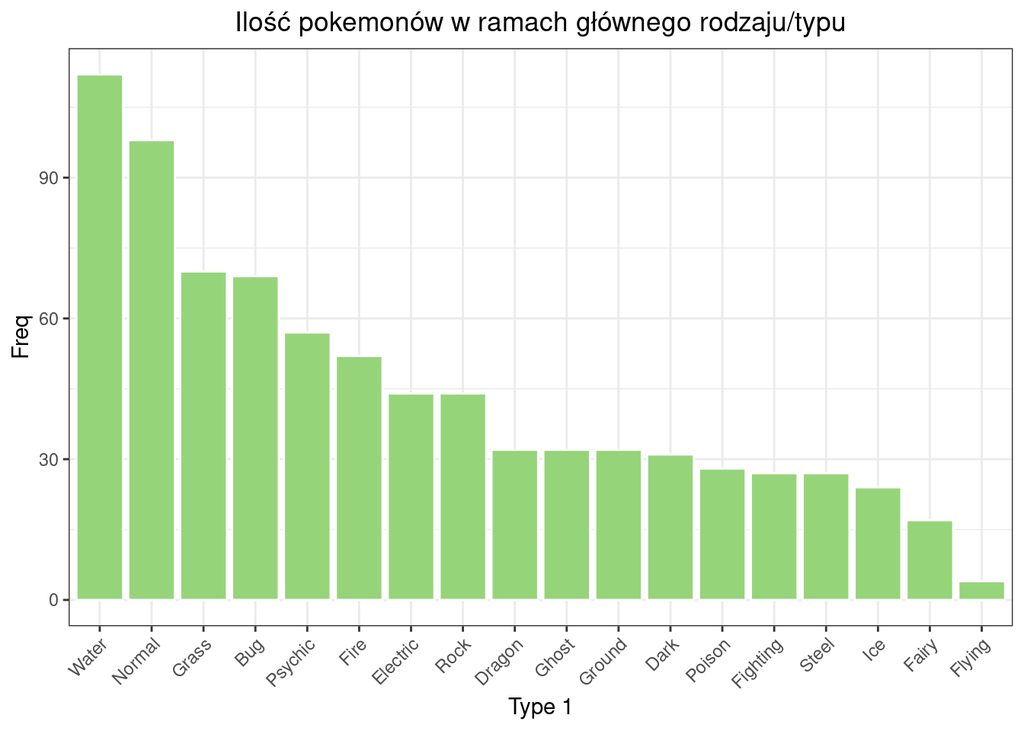

```r
ggplot(pokemon, aes(x=fct_infreq(Type.1))) +
  geom_bar(fill="#96D47A", colour="white") +
  labs(x="Type 1", y="Freq",
       title="Ilość pokemonów w ramach głównego rodzaju/typu") +
  theme_bw() +
  theme(axis.text.x=element_text(angle=45, hjust=1)) +
  theme(plot.title = element_text(hjust = 0.5))
```

- zestawienie tabelaryczne ilości oraz częstości występowania głównego rodzaju pokemonów:

```r
pokemon %>%
  group_by(Type.1) %>%
  summarise(ilosc = n()) %>%
  mutate(freq = round(ilosc/ sum(ilosc), 3)) %>%
  arrange(desc(freq))
```

| Type.1 | ilosc | freq |
| --- | --- | --- |
| Water | 112 | 0.140 |
| Normal | 98 | 0.122 |
| Grass | 70 | 0.088 |
| Bug | 69 | 0.086 |
| Psychic | 57 | 0.071 |
| Fire | 52 | 0.065 |
| Electric | 44 | 0.055 |
| Rock | 44 | 0.055 |
| Dragon | 32 | 0.040 |
| Ghost | 32 | 0.040 |

[output cut: 8 more lines]

- zestawienie tabelaryczne ilości oraz częstości występowania dodatkowego rodzaju/typu pokemonów.

```r
pokemon %>%
  group_by(Type.2) %>%
  summarise(ilosc = n()) %>%
  mutate(freq = round(ilosc/ sum(ilosc), 3)) %>%
  arrange(desc(freq))
```

| Type.2 | ilosc | freq |
| --- | --- | --- |
|  | 386 | 0.482 |
| Flying | 97 | 0.121 |
| Ground | 35 | 0.044 |
| Poison | 34 | 0.042 |
| Psychic | 33 | 0.041 |
| Fighting | 26 | 0.032 |
| Grass | 25 | 0.031 |
| Fairy | 23 | 0.029 |
| Steel | 22 | 0.028 |
| Dark | 20 | 0.025 |

[output cut: 9 more lines]

- kombinacje dwóch rodzajów typów pokemonów:

```r
typy <- pokemon %>%
  group_by(Type.1, Type.2) %>%
  summarise(count=n())
```

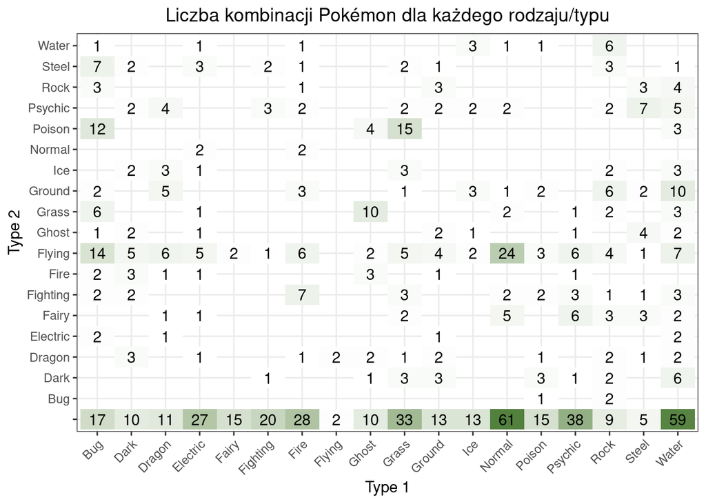

```r
ggplot(typy, aes(x=Type.1,y=Type.2)) +
  geom_tile(aes(fill=count), show.legend=FALSE) +
  geom_text(aes(label=count)) +
  theme_bw() +
  theme(axis.text.x=element_text(angle=45, hjust=1)) +
  labs(x="Type 1", y="Type 2",
       title="Liczba kombinacji Pokémon dla każdego rodzaju/typu") +
       theme(plot.title = element_text(hjust = 0.5)) +
  scale_fill_gradient(low="white", high="#52803D")
```

-zestawienie liczbowe kombinacji rodzajów/typów pokemonów

```r
# Counts of each type combination
pokemon %>%
  group_by(Type.1, Type.2) %>%
  summarise(ilosc=n()) %>%
  mutate(freq = round(ilosc/ nrow(pokemon), 3)) %>%
  arrange(desc(ilosc))
```

| Type.1 | Type.2 | ilosc | freq |
| --- | --- | --- | --- |
| Normal |  | 61 | 0.076 |
| Water |  | 59 | 0.074 |
| Psychic |  | 38 | 0.048 |
| Grass |  | 33 | 0.041 |
| Fire |  | 28 | 0.035 |
| Electric |  | 27 | 0.034 |
| Normal | Flying | 24 | 0.030 |
| Fighting |  | 20 | 0.025 |
| Bug |  | 17 | 0.021 |
| Fairy |  | 15 | 0.019 |

[output cut: 144 more lines]

Wnioski: Opisywany zbiór danych pokemon posiada dwa główne rodzaje (Type.1), które występowały najczęściej tj. Water oraz Normal. Ponadto, występują liczne różne kombinacje rodzaju głównego (Type.1) z rodzajem dodatkowym (Type.2). Wstępnie zakładam, że taka różnorodność połączeń rodzaju głównego z dodatkowymi, może utrudnić grupowanie tych danych.

**2. Grupowanie algorytmem partycjonującym**

Selekcja zmiennych:

Wydaje się, że uzasadnione jest usunięcie następujących atrybutów z danej analizy: - X. - stanowiącej indeks - brak dodatkowej wiedzy płynącej z tej zmiennej, - Type.1 - cel zadania - teoretycznie wartość docelowa, - Type.2 - jw., - Total - podsumowanie poszczególnych statystyk - informacje te zawierają inne zmienne (suma ich wartości), - Generation - generacja serii TV Pokemon (czyt. jako sezony Pokemon) - zmienna nieistotna z punktu widzenia grupowania pokemonów w klastry według rodzaju, - Legendary - zmienna binarna - zostanie usunięta ponieważ to czy Pokemon jest legendarny czy też nie nie wpływa na jego rodzaj główny; pokemon legendary może być takiego samego typu jak inne pokemony np. Grass, Fire itd.

```r
pokeData <- pokemon %>%
              select(-c(X., Name, Type.1, Type.2, Total, Generation, Legendary))

head(pokeData)
```

|  | HP | Attack | Defense | Sp..Atk | Sp..Def | Speed |
| --- | --- | --- | --- | --- | --- | --- |
| 1 | 45 | 49 | 49 | 65 | 65 | 45 |
| 2 | 60 | 62 | 63 | 80 | 80 | 60 |
| 3 | 80 | 82 | 83 | 100 | 100 | 80 |
| 4 | 80 | 100 | 123 | 122 | 120 | 80 |
| 5 | 39 | 52 | 43 | 60 | 50 | 65 |
| 6 | 58 | 64 | 58 | 80 | 65 | 80 |

- Skalowanie danych:

```r
dataPokScale <- scale(pokeData, center = FALSE)
dataPokScale <- as.data.frame(dataPokScale)

#head(dataPokScale)
```

- Losowo wybrane 25% danych do ustalenia ilości grup - x próbek:

```r
set.seed(15151)

#?sample_frac()
sampleData <- list()
noSample <- 6

for(i in 1:noSample)
  {
   sampleData[[i]] <- sample_frac(dataPokScale, 0.25)
 }
```

**2a) Wyznaczenie liczby grup dla algorytmu k-środków metodą „łokcia” przy wykorzystaniu 25% losowo wybranych danych – sprawdzenie dla kilku przykładów:**

```r
cElbow <- list()
cASill <- list()

for(i in 1:length(sampleData))
  {
   cElbow[[i]] <- fviz_nbclust(sampleData[[i]],FUNcluster=kmeans,method = "wss",linecolor = "#46A11C") + ggtitle(paste("WSS, sample no:",i))
   cASill[[i]] <- fviz_nbclust(sampleData[[i]],FUNcluster=kmeans,method = "s",linecolor = "#46A11C") + ggtitle(paste("Avg Sil Width, \nsample no:",i))
   }

#z dokumentacji: https://www.datanovia.com/en/lessons/determining-the-optimal-number-of-clusters-3-must-know-methods/
```

- wyświetlenie wyników doboru ilości grup metodą łokcia:

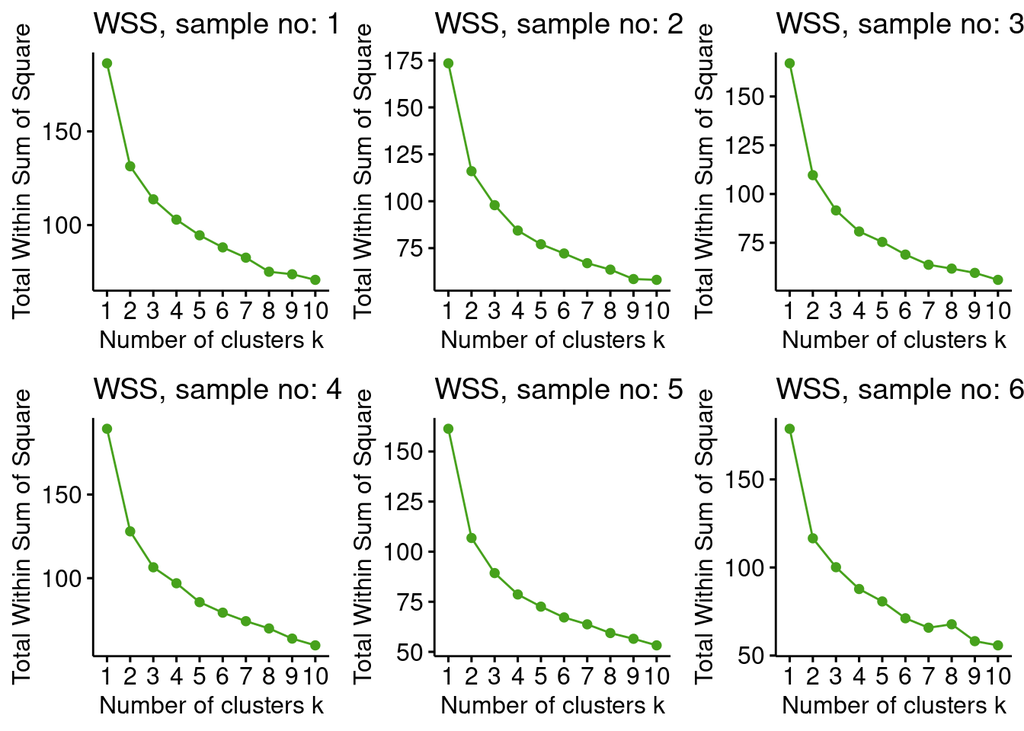

```r
do.call('grid.arrange',c(cElbow, ncol = 3))
```

- wyświetlenie wyników doboru liczby grup dla metody Average Silhouette Width:

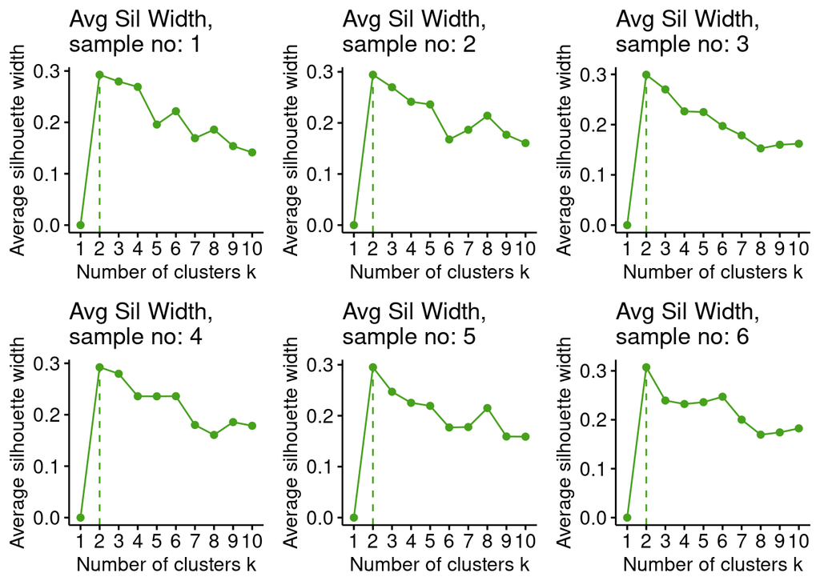

```r
do.call('grid.arrange',c(cASill, ncol = 3))
```

- wyniki dla całej populacji:

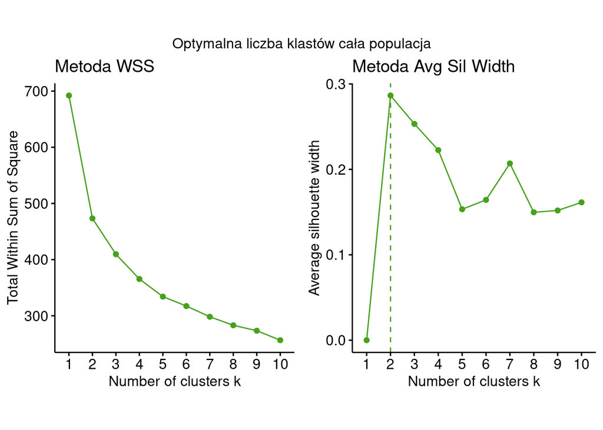

```r
elbowAll <- fviz_nbclust(dataPokScale,FUNcluster=kmeans,method = "wss",linecolor = "#46A11C") + ggtitle(paste("Metoda WSS"))
asvAll <- fviz_nbclust(dataPokScale,FUNcluster=kmeans,method = "s",linecolor = "#46A11C") + ggtitle(paste("Metoda Avg Sil Width"))

grid.arrange(elbowAll,asvAll,heights=unit(0.8, "npc") , top = "Optymalna liczba klastów cała populacja")
```

Wnioski: Mając na uwadze powyżej otrzymane wykresy dot. metody łokcia oraz avarage sillhouette width, można zidentyfikować punkt “przegięcia” dla wartości 2. W konsekwencji ustalam liczbę grup równą 2.

**2b) Wykonanie grupowania z różnymi wartościami parametrów (np. zastosowanej miary odległości w algorytmie k-środków):**

- różne implementacje algorytmu k-means:

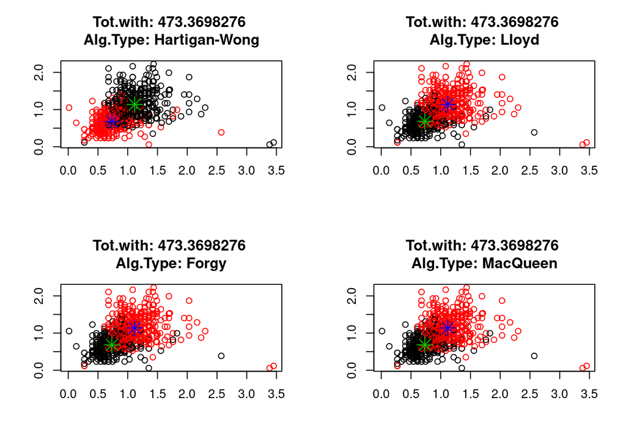

```r
algs = c("Hartigan-Wong", "Lloyd", "Forgy","MacQueen")

par(mfrow = c(2, 2))
set.seed(1)

for(i in 1:4)
  {
    poke.kmeansS = kmeans(dataPokScale,2,nstart = 1, iter.max = 40, algorithm = algs[i] )
    #drukuj wykres
    plot(dataPokScale[1:2], col = poke.kmeansS$cluster,
         main = paste("Tot.with:", round(poke.kmeansS$tot.withinss,7), "\nAlg.Type:", algs[i]),
         xlab = "", ylab = "")
    points(poke.kmeansS$centers[,1:2], col = 3:4, pch = 8, cex=2)
  }
```

Wnioski: Otrzymane wyniki w zakresie różnych implementacji algorytmu kmeans są właściwie identyczne dla k = 2.

-Zapisanie wyników dot. ilości grup i utworzonego grupowania:

```r
#ilość grup
g <- 2

#informacje dot. grupowania (kmeans)
poke.kmeansS = kmeans(dataPokScale,g,nstart = 1, iter.max = 40)
poke.kmeansS
```

```
## K-means clustering with 2 clusters of sizes 426, 374
##
## Cluster means:
##          HP    Attack   Defense   Sp..Atk  Sp..Def     Speed
## 1 1.1174745 1.1364791 1.1138605 1.1380055 1.142397 1.0928003
## 2 0.7330291 0.6830095 0.7007597 0.6538563 0.692521 0.7223982
##
## Clustering vector:
##   [1] 2 2 1 1 2 2 1 1 1 2 2 1 1 2 2 2 2 2 2 1 2 2 1 1 2 2 2 1 2 1 2 1 2 1 2 2 1
##  [38] 2 2 1 2 1 2 1 2 1 2 1 2 2 1 2 2 2 1 2 2 2 1 2 1 2 1 2 1 2 2 1 2 2 1 1 2 2
##  [75] 1 2 2 1 2 1 2 2 1 2 1 2 1 1 2 1 2 2 1 2 1 2 1 2 1 2 2 1 1 2 2 1 2 1 2 1 2
## [112] 1 2 2 1 1 2 2 1 2 1 1 1 1 1 2 1 2 1 2 1 1 1 1 1 1 1 1 1 2 1 1 1 2 2 1 1 1
## [149] 2 2 1 2 1 1 1 1 1 1 1 2 2 1 1 1 1 1 2 2 1 2 2 1 2 2 1 2 2 2 1 2 2 2 2 1 2
## [186] 1 2 2 2 2 2 2 1 2 2 1 1 1 2 2 2 1 2 2 1 2 2 1 2 2 1 1 1 2 1 1 2 2 1 2 1 2
## [223] 2 1 1 2 1 2 1 1 1 1 1 2 2 1 2 2 2 1 2 2 1 2 1 1 2 1 1 1 2 1 1 1 2 2 1 2 2
## [260] 2 1 1 1 1 1 2 2 1 1 1 1 1 2 2 1 1 2 2 1 1 2 2 1 1 2 2 2 2 2 2 2 2 2 2 2 1
## [297] 2 2 1 2 2 2 1 2 2 1 1 2 2 2 1 2 1 1 2 1 2 2 2 1 2 1 2 2 2 2 2 1 2 1 2 2 1
## [334] 1 2 2 1 2 1 1 2 2 2 2 2 2 1 2 1 1 2 1 2 1 1 1 2 1 2 2 2 1 2 1 2 1 1 1 1 1
## [371] 1 2 1 2 1 2 1 2 1 2 1 2 1 2 1 2 1 1 2 1 1 1 1 1 2 2 1 1 2 2 1 2 1 1 1 2 2
## [408] 2 1 1 2 2 1 1 1 1 1 1 1 1 1 1 1 1 1 1 1 1 1 1 1 1 2 2 1 2 2 1 2 2 1 2 2 1
## [445] 2 2 2 2 2 2 1 2 1 2 1 2 1 2 1 2 2 2 2 1 2 2 1 2 1 2 1 1 2 1 2 1 1 1 1 2 1
## [482] 2 2 1 2 1 2 2 2 2 1 2 2 1 1 2 2 1 1 2 1 2 1 2 1 1 2 1 2 2 1 1 1 1 1 1 1 1
## [519] 1 1 1 1 1 1 1 1 1 1 1 1 1 1 1 1 1 1 1 1 1 1 1 1 1 1 1 1 1 1 1 1 1 1 1 1 2
## [556] 2 1 2 2 1 2 2 1 2 2 2 2 1 2 1 2 1 2 1 2 1 2 1 2 2 1 2 1 2 2 1 2 2 2 1 1 1
## [593] 2 2 1 2 2 1 1 1 2 2 1 2 2 1 2 1 2 1 1 2 2 1 2 1 1 1 2 1 2 1 1 2 1 2 1 2 1
## [630] 2 1 2 1 2 1 2 2 1 2 2 1 2 1 2 2 1 2 1 2 2 1 2 1 2 1 1 2 1 2 1 2 1 1 2 2 1
## [667] 2 1 2 2 1 2 2 1 2 1 1 2 1 1 2 1 1 2 1 2 1 1 2 1 2 1 1 1 2 2 1 2 1 1 1 1 1
## [704] 1 1 1 1 1 1 1 1 1 1 1 1 1 1 1 2 2 1 2 2 1 2 2 1 2 2 2 2 1 2 2 2 2 1 2 2 1
## [741] 2 1 2 1 1 2 1 1 2 1 1 1 2 1 2 1 2 1 2 1 2 1 2 1 2 1 2 1 2 1 1 1 1 1 2 1 1
## [778] 1 2 1 2 2 2 2 1 1 1 1 2 1 2 1 1 1 1 1 1 1 1 1
##
## Within cluster sum of squares by cluster:
## [1] 331.4507 141.9191
##  (between_SS / total_SS =  31.6 %)
##
## Available components:
##
## [1] "cluster"      "centers"      "totss"        "withinss"     "tot.withinss"
## [6] "betweenss"    "size"         "iter"         "ifault"
```

**2c) Ocena jakości grupowa przy użyciu indeksu Silhouette.**

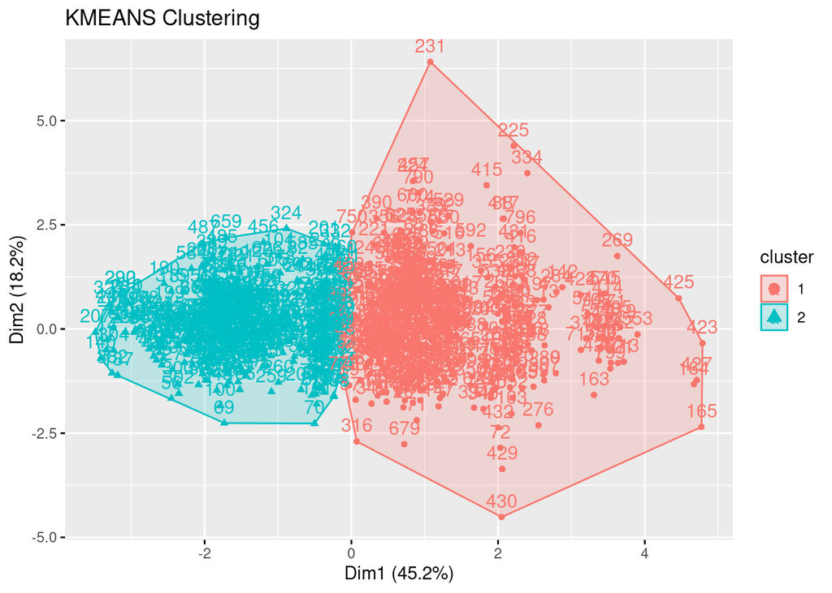

```r
km_alt<-eclust(dataPokScale, "kmeans", k = g, graph=T)
```

```
##   cluster size ave.sil.width
## 1       1  426          0.17
## 2       2  374          0.42
```

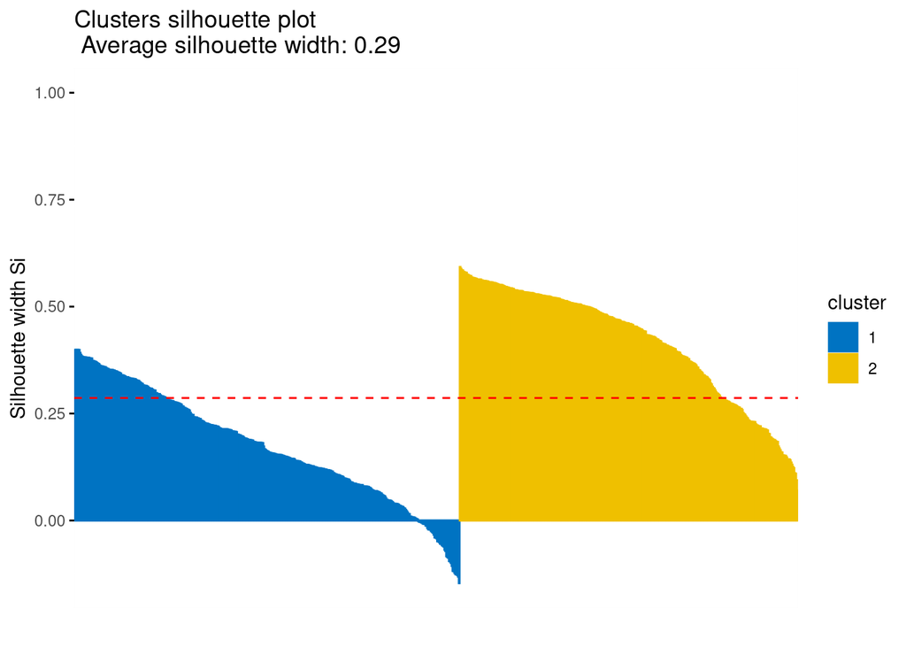

```r
fviz_silhouette(km_alt, palette="jco")
```

```r
#lub

#?fviz_silhouette
#PokKmeanSsil <- silhouette(poke.kmeansS$cluster, dist(dataPokScale))
#fviz_silhouette(PokKmeanSsil)
```

-sprawdzam, dla których obserwacji index Silhouette przyjmuje wartności niższe od zera:

```r
# Silhouette width of observation
km.res <- eclust(dataPokScale, "kmeans", k = g, nstart = 25, graph = FALSE)

# Silhouette width of observation
sil <- km.res$silinfo$widths[, 1:3]

# Objects with negative silhouette
neg_sil_index <- which(sil[, 'sil_width'] < 0)
negativeSil <- sil[neg_sil_index, , drop = FALSE]
head(negativeSil)
```

|  | cluster | neighbor | sil_width |
| --- | --- | --- | --- |
| 246 | 1 | 2 | -0.001924148 |
| 205 | 1 | 2 | -0.003295251 |
| 776 | 1 | 2 | -0.003365847 |
| 311 | 1 | 2 | -0.004725598 |
| 93 | 1 | 2 | -0.005690490 |
| 219 | 1 | 2 | -0.007702813 |

```r
#nrow(negativeSil)/nrow(dataPokScale) #ile procent obserwacji dla których index Sil jest mniejszy od zera

#z dokumentacji: https://www.datanovia.com/en/lessons/cluster-validation-statistics-must-know-methods/
```

Wnioski: Otrzymane rezultaty w przypadku pierwszego klastra nie są zadawalające, część obserwacji (ok. 6%) została zle przydzielona do danej grupy (index Silhouette przyjął wartości mniejsze od zera). Lepiej prezentuje się drugi klaster dla którego ww. indeks przyjmuje wartości dodatnie co oznacza dobre przydzielenie danej obserwacji do klastra.

**2d) Przypisanie poszczególnych rekordów do grup:**

```r
pokemon$Groupe <- poke.kmeansS$cluster

head(pokemon)
```

|  | X. | Name | Type.1 | Type.2 | Total | HP | Attack | Defense | Sp..Atk | Sp..Def | Speed | Generation | Legendary | Groupe |
| --- | --- | --- | --- | --- | --- | --- | --- | --- | --- | --- | --- | --- | --- | --- |
| 1 | 1 | Bulbasaur | Grass | Poison | 318 | 45 | 49 | 49 | 65 | 65 | 45 | 1 | False | 2 |
| 2 | 2 | Ivysaur | Grass | Poison | 405 | 60 | 62 | 63 | 80 | 80 | 60 | 1 | False | 2 |
| 3 | 3 | Venusaur | Grass | Poison | 525 | 80 | 82 | 83 | 100 | 100 | 80 | 1 | False | 1 |
| 4 | 3 | VenusaurMega Venusaur | Grass | Poison | 625 | 80 | 100 | 123 | 122 | 120 | 80 | 1 | False | 1 |
| 5 | 4 | Charmander | Fire |  | 309 | 39 | 52 | 43 | 60 | 50 | 65 | 1 | False | 2 |
| 6 | 5 | Charmeleon | Fire |  | 405 | 58 | 64 | 58 | 80 | 65 | 80 | 1 | False | 2 |

- wyświetlenie rezultatów kmeans clustering:

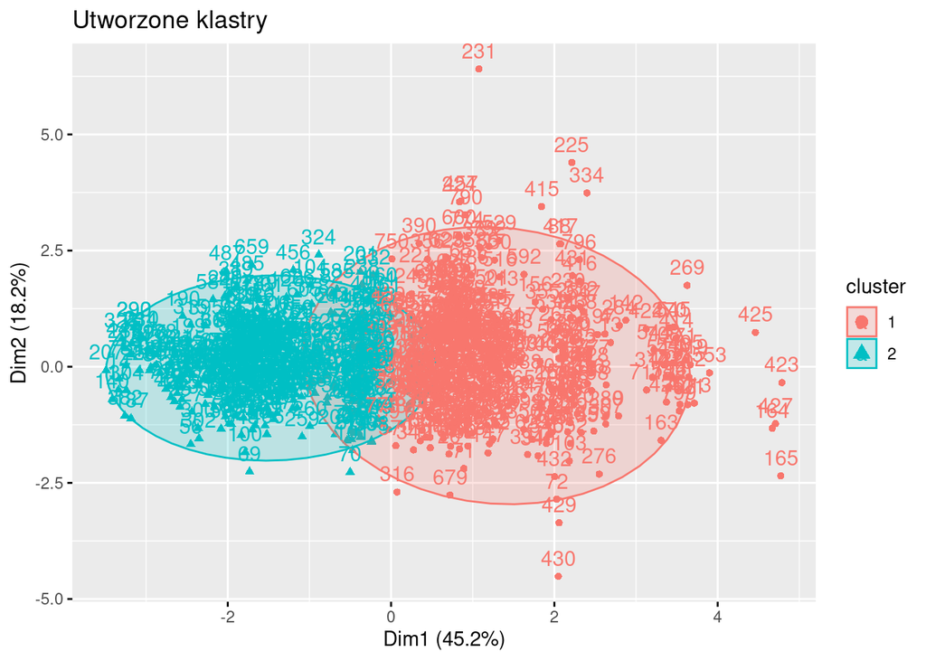

```r
#?fviz_cluster
fviz_cluster(poke.kmeansS, dataPokScale, main = "Utworzone klastry", ellipse.type = "norm")
```

**2e) Znalezienie charakterystycznych elementów grup**

- zweryfikowanie liczności poszczególnych grup:

```r
poke.kmeansS$size
```

```
## [1] 426 374
```

Obie grupy mają zbliżone wielkości.

- analiza centrów poszczególnych atrybutów grup (dla wartości znormalizowanych):

```r
#?kmeans
poke.kmeansS$centers
```

```
##          HP    Attack   Defense   Sp..Atk  Sp..Def     Speed
## 1 1.1174745 1.1364791 1.1138605 1.1380055 1.142397 1.0928003
## 2 0.7330291 0.6830095 0.7007597 0.6538563 0.692521 0.7223982
```

Otrzymane wyniki wydają się dość przewidywalne, a szersza znajomość tematu świata pokemon może przynieść odpowiedzi dlaczego mamy do czynienia z taką sytuacją i dlaczego w ramach budowy klastrów otrzymaliśmy dwa klastry. Jest to związane min. z ewolucją pokemonów tj. mam doczynienia z tym samym osobnikiem o takim samym rodzaju główny (Type.1) i dodatkowym (Type.2) ale na różnym poziomie rozwoju (stąd wyższe parametry opisujące).

**3. Grupowanie algorytmem DBSCAN**

**3a) Wyznaczenie parametru eps dla algorytmu DBSCAN metodą szukania punktu przegięcie z wykorzystaniem 25% losowo wybranych danych – sprawdzenie dla kilku wartości K**

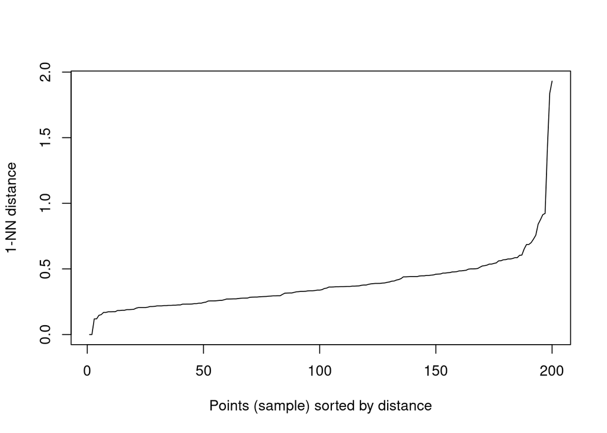

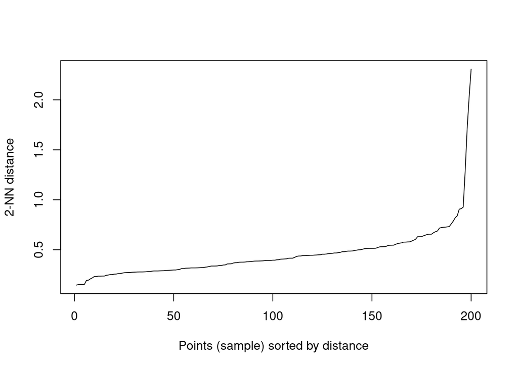

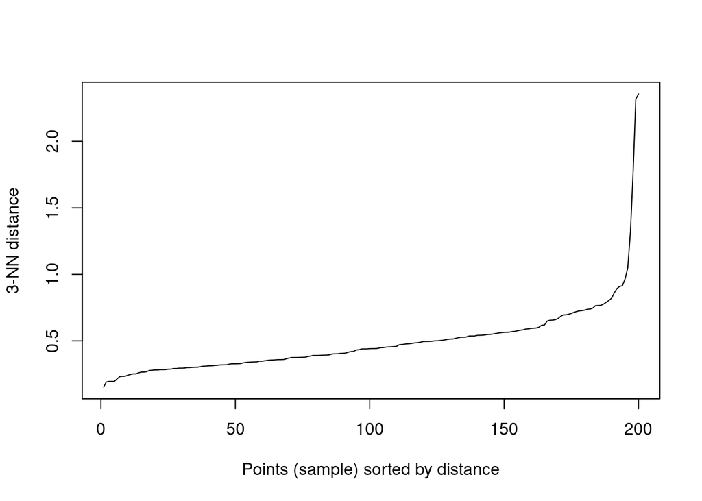

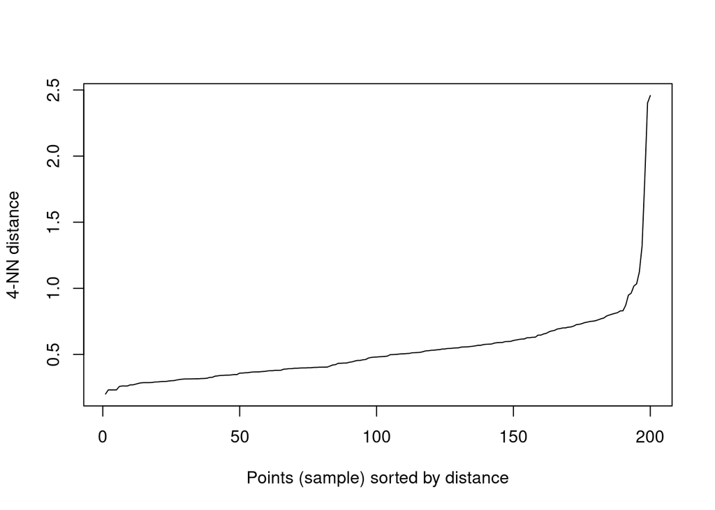

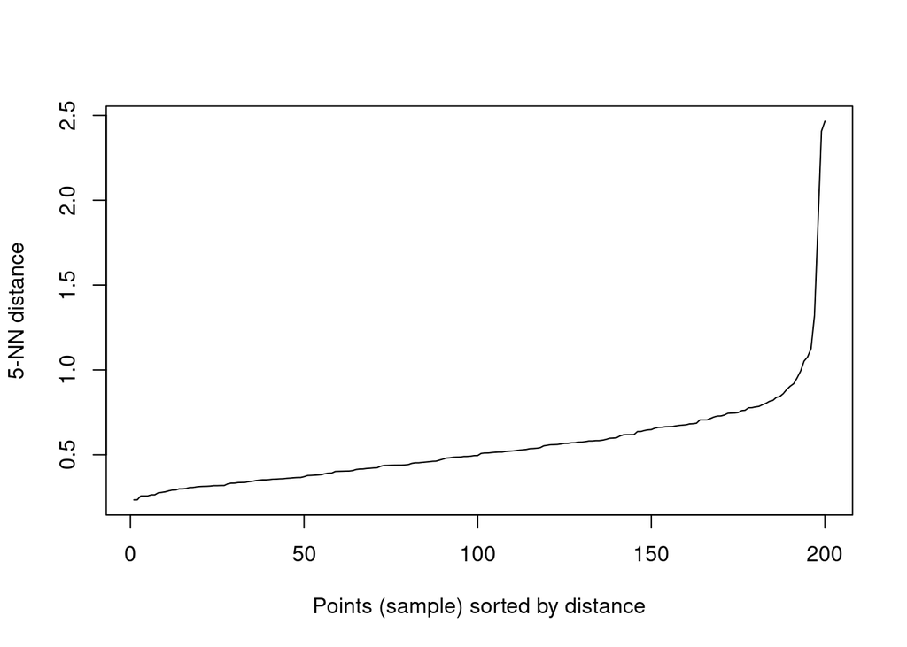

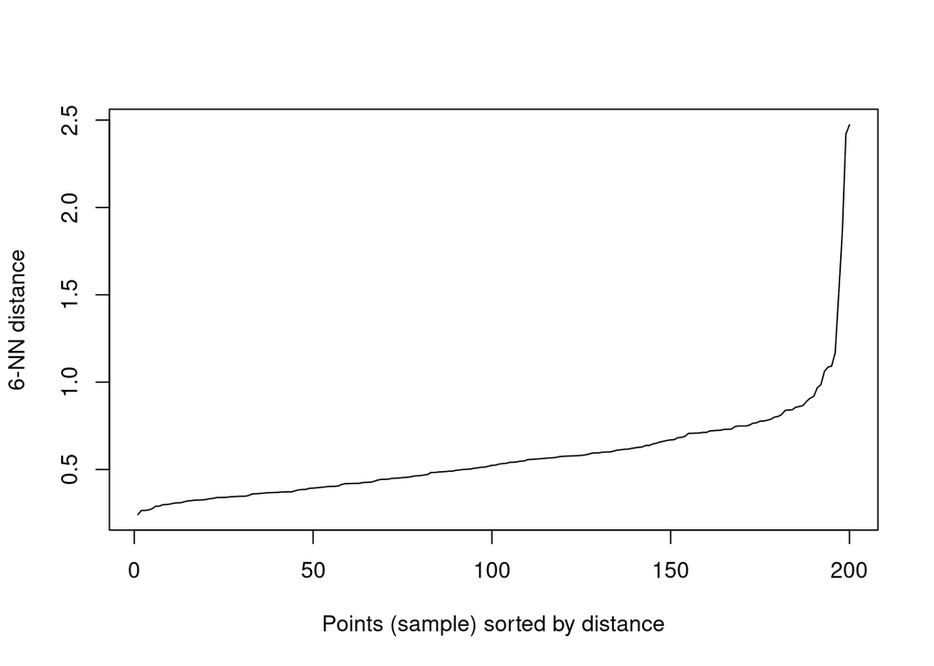

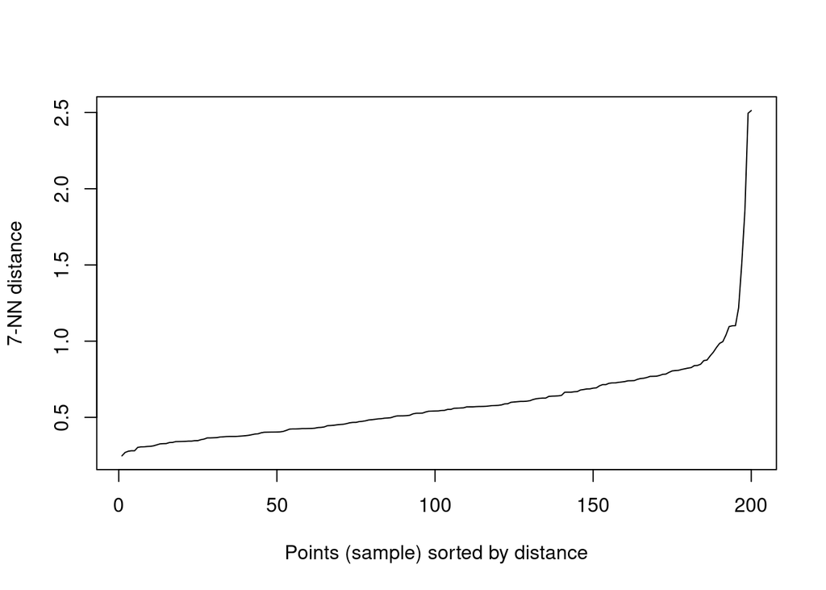

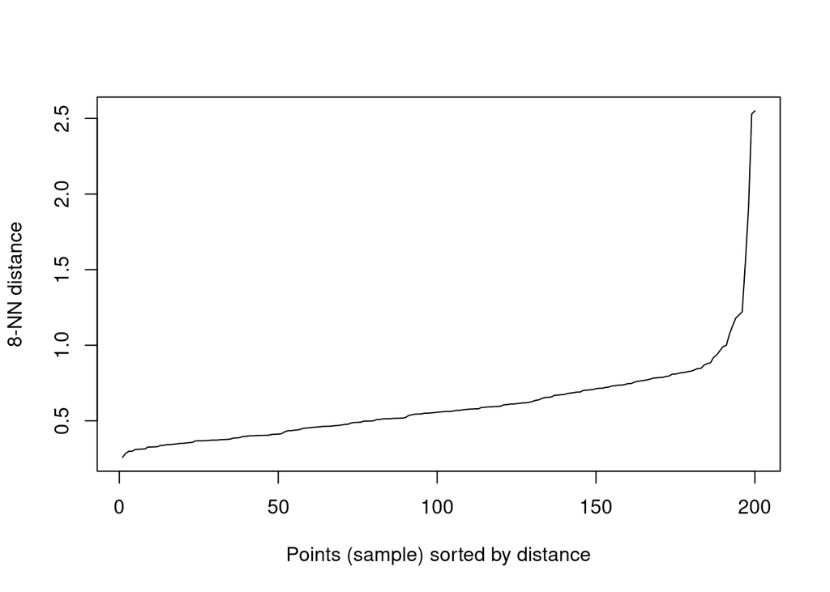

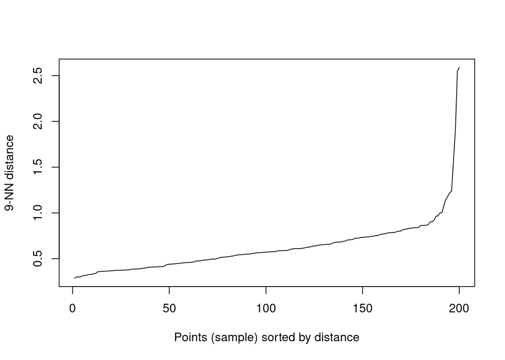

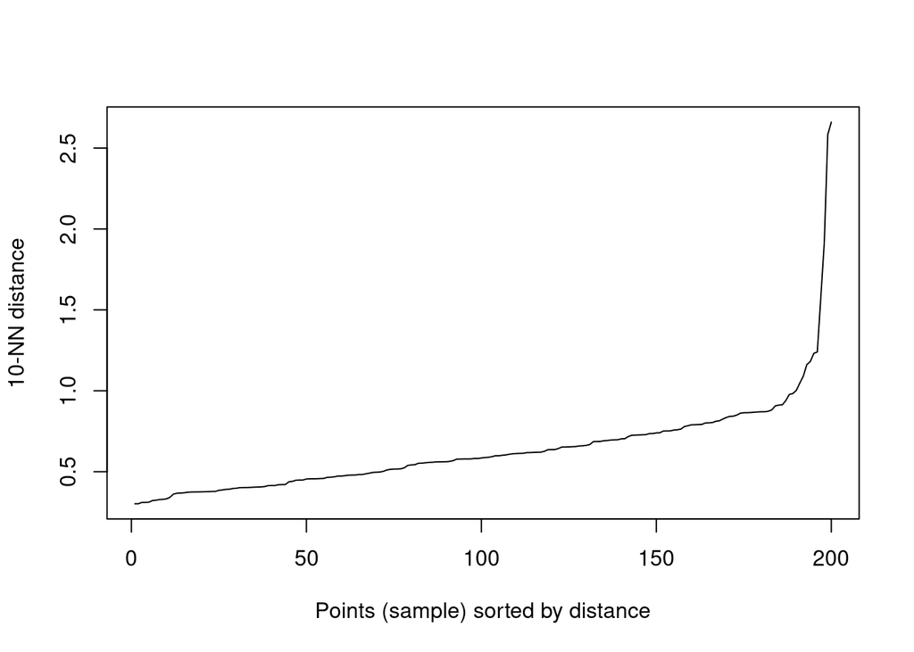

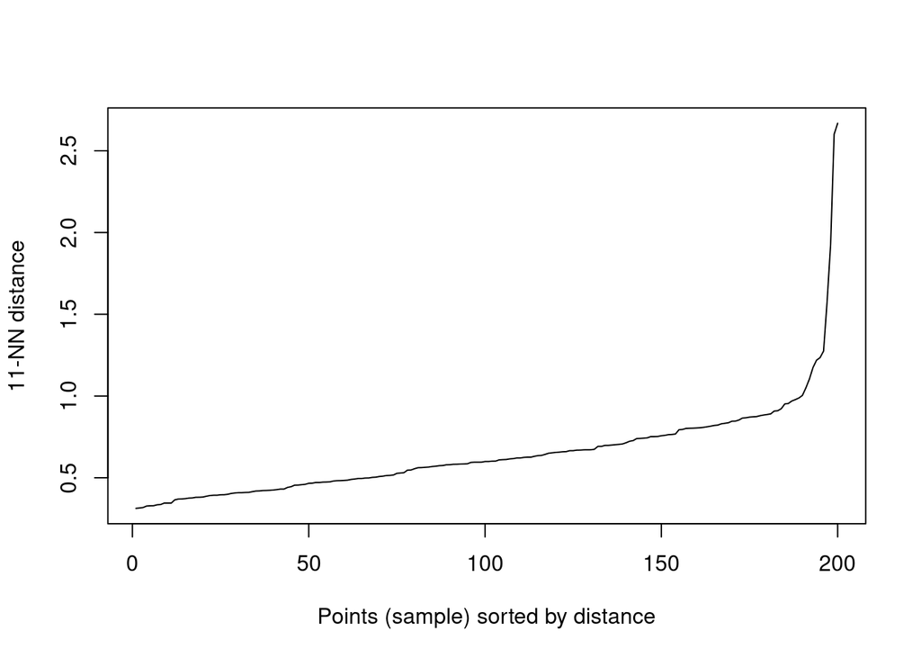

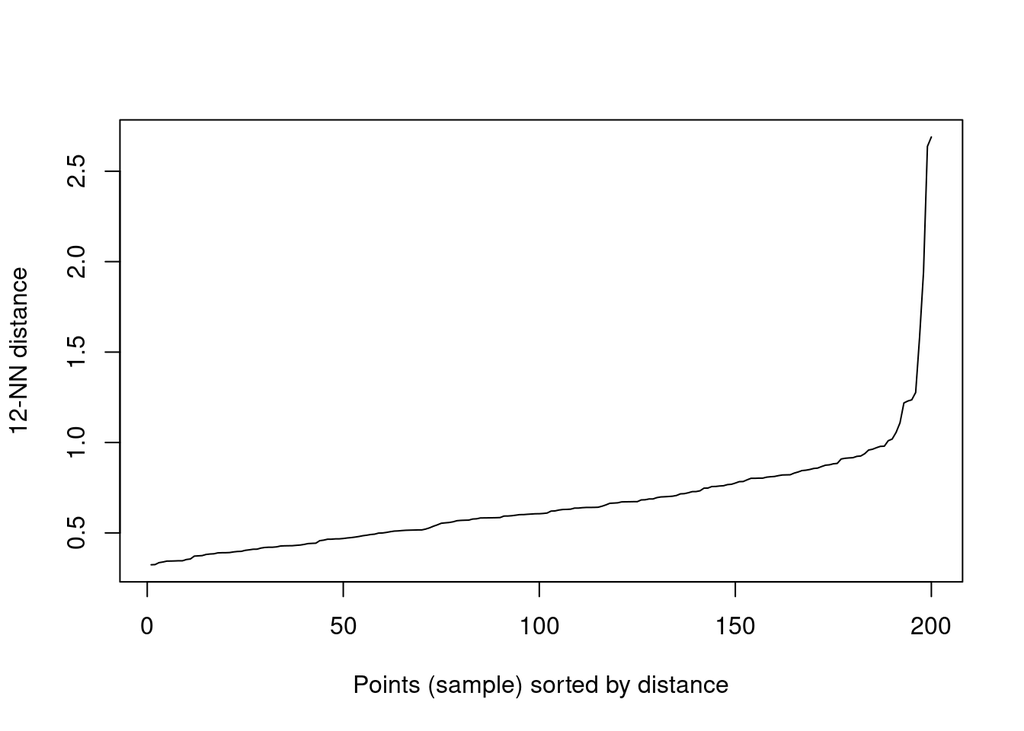

[1 more figures not shown]

```r
set.seed(15151)
PokeSilSample <- sample_frac(dataPokScale, 0.25)

dbSCAN <- list()

minPtsTest <- seq(2, 14, by = 1)

for(i in 1:length(minPtsTest))
  {
    dbSCAN[[i]] <- kNNdistplot(PokeSilSample, k = i)
    }
```

Wnioski: Analizując powyżej otrzymane wykresy, można zauważyć, że dla zadanych k z przedziału <1,14> punkt przełamania krzywej znajduje się dla wartości od 0.5 do 0.75. W dalszej części analizy zostaną zweryfikowane poszczególne kombinacje tych parametrów i otrzymane rezultaty (ilości klastrów).

**3b) Wykonanie grupowania dla kilku zestawów wartości parametrów.**

```r
#?dbscan
epsTest <-seq(0.5, 0.75, by = 0.05)
minPtsTest <- seq(2,length(epsTest)*2,2)

for(i in 1:length(minPtsTest)) {

  for(j in 1:length(minPtsTest)) {
   print(paste("epsTest = ",epsTest[i]," >>>>>>  minPtsTest = ",minPtsTest[j]))
   print(summary(silhouette(dbscan::dbscan(dataPokScale, eps = epsTest[i], minPts = minPtsTest[j])$cluster, dist(dataPokScale))))
   print("----------------------------------------------")
  }
}
```

```
## [1] "epsTest =  0.5  >>>>>>  minPtsTest =  2"
## Silhouette of 800 units in 11 clusters from silhouette.default(x = dbscan::dbscan(dataPokScale, eps = epsTest[i],  from     minPts = minPtsTest[j])$cluster, dist = dist(dataPokScale)) :
##  Cluster sizes, ids = (0, 1, 2, 3, 4, 5, 6, 7, 8, 9, 10), and average silhouette widths:
##          47         732           2           2           2           2
## -0.46425671  0.02152653  0.30864579  0.77321327  0.67177421  0.71836666
##           2           2           2           2           5
##  0.38401461  0.50650929  0.25353279  0.74875051  0.66105148
## Individual silhouette widths:
##      Min.   1st Qu.    Median      Mean   3rd Qu.      Max.
## -0.744032 -0.178191  0.071595  0.007465  0.214796  0.790421
## [1] "----------------------------------------------"
## [1] "epsTest =  0.5  >>>>>>  minPtsTest =  4"
## Silhouette of 800 units in 3 clusters from silhouette.default(x = dbscan::dbscan(dataPokScale, eps = epsTest[i],  from     minPts = minPtsTest[j])$cluster, dist = dist(dataPokScale)) :
##  Cluster sizes, ids = (0, 1, 2), and average silhouette widths:
##         70        725          5
## -0.2008022  0.3087045  0.7337956
## Individual silhouette widths:
##    Min. 1st Qu.  Median    Mean 3rd Qu.    Max.
## -0.6320  0.1709  0.3373  0.2668  0.4307  0.7716
## [1] "----------------------------------------------"
## [1] "epsTest =  0.5  >>>>>>  minPtsTest =  6"
## Silhouette of 800 units in 3 clusters from silhouette.default(x = dbscan::dbscan(dataPokScale, eps = epsTest[i],  from     minPts = minPtsTest[j])$cluster, dist = dist(dataPokScale)) :
##  Cluster sizes, ids = (0, 1, 2), and average silhouette widths:
##         86        709          5
## -0.2510843  0.2483583  0.7740551
## Individual silhouette widths:
##     Min.  1st Qu.   Median     Mean  3rd Qu.     Max.
## -0.67287  0.01312  0.29899  0.19795  0.43938  0.83634
## [1] "----------------------------------------------"
## [1] "epsTest =  0.5  >>>>>>  minPtsTest =  8"
## Silhouette of 800 units in 2 clusters from silhouette.default(x = dbscan::dbscan(dataPokScale, eps = epsTest[i],  from     minPts = minPtsTest[j])$cluster, dist = dist(dataPokScale)) :
##  Cluster sizes, ids = (0, 1), and average silhouette widths:
##          99         701
## -0.08912718  0.35154477
## Individual silhouette widths:
##    Min. 1st Qu.  Median    Mean 3rd Qu.    Max.
## -0.4017  0.2144  0.3543  0.2970  0.4490  0.5177
## [1] "----------------------------------------------"
## [1] "epsTest =  0.5  >>>>>>  minPtsTest =  10"
## Silhouette of 800 units in 2 clusters from silhouette.default(x = dbscan::dbscan(dataPokScale, eps = epsTest[i],  from     minPts = minPtsTest[j])$cluster, dist = dist(dataPokScale)) :
```

[output cut: 271 more lines]

```
##         13        787
## -0.1876955  0.4780828
## Individual silhouette widths:
##    Min. 1st Qu.  Median    Mean 3rd Qu.    Max.
## -0.3517  0.4268  0.4982  0.4673  0.5485  0.6068
## [1] "----------------------------------------------"
## [1] "epsTest =  0.75  >>>>>>  minPtsTest =  12"
## Silhouette of 800 units in 2 clusters from silhouette.default(x = dbscan::dbscan(dataPokScale, eps = epsTest[i],  from     minPts = minPtsTest[j])$cluster, dist = dist(dataPokScale)) :
##  Cluster sizes, ids = (0, 1), and average silhouette widths:
##         13        787
## -0.1876955  0.4780828
## Individual silhouette widths:
##    Min. 1st Qu.  Median    Mean 3rd Qu.    Max.
## -0.3517  0.4268  0.4982  0.4673  0.5485  0.6068
## [1] "----------------------------------------------"
```

Wnioski: Zgodnie z oczekiwaniami otrzymaliśmy przy mniejszych wartościach minPts więcej utworzonych klastrów i na odwrót. Najlepiej oceniona konfiguracja eps oraz minPts parametrami Silhouette to eps = 0.75 oraz minPts =4. Niemniej jednak w ramach tego grupowania otrzymaliśmy jedną grupę (defakto brak grupowania) i bardzo niską ilośc punktów szumowych. Można by było próbować szukać kombinacji parametrów algorytmu DBSCAN, dla których otrzymamy większą liczbę klastrów przy wartościch indeksu Sillhouette > 0. Niemniej jednak, nawet jeżeli występują takie kombinacje to są one na tle całej populacji małoliczne - parę obiektów.

Wybranie finalnych wartości eps oraz minPts oraz utworzenie klastrów w ramach algorytmu DBSCAN:

```r
epsFinal <- 0.75
minPtsFinal <- 4

dbscan.out <-  dbscan::dbscan(dataPokScale, eps = epsFinal, minPts = minPtsFinal)
```

**3c) Ocena jakości grupowa przy użyciu indeksu Silhouette.**

```r
#?silhouette
sil.dbscan <- silhouette(dbscan.out$cluster, dist(dataPokScale))
summary(sil.dbscan)
```

```
## Silhouette of 800 units in 2 clusters from silhouette.default(x = dbscan.out$cluster, dist = dist(dataPokScale)) :
##  Cluster sizes, ids = (0, 1), and average silhouette widths:
##          9        791
## -0.1958130  0.4917625
## Individual silhouette widths:
##    Min. 1st Qu.  Median    Mean 3rd Qu.    Max.
## -0.3929  0.4487  0.5120  0.4840  0.5552  0.6155
```

```r
#PokKmeanSsil <- silhouette(poke.kmeansS$cluster, dist(dataPokScale))
```

- graficzna prezentacja wyników w ramach oceny grupowania wartościami indeksu Silhouette.

```
##   cluster size ave.sil.width
## 0       0    9         -0.20
## 1       1  791          0.49
```

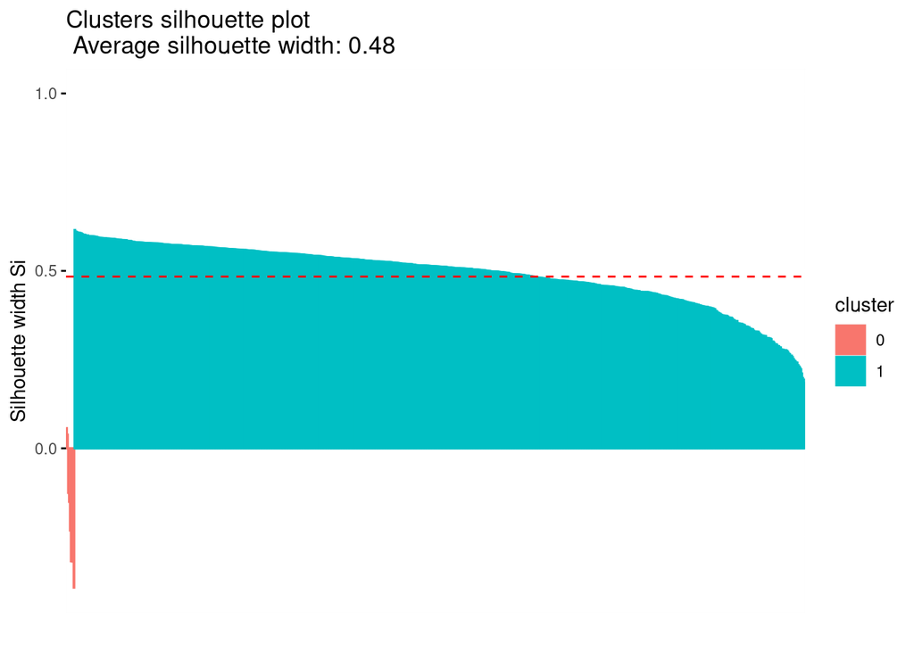

```r
fviz_silhouette(sil.dbscan)
```

-prezentacja graficzna dokonanego grupowania danych pokemon algorytmem DBSCAN.

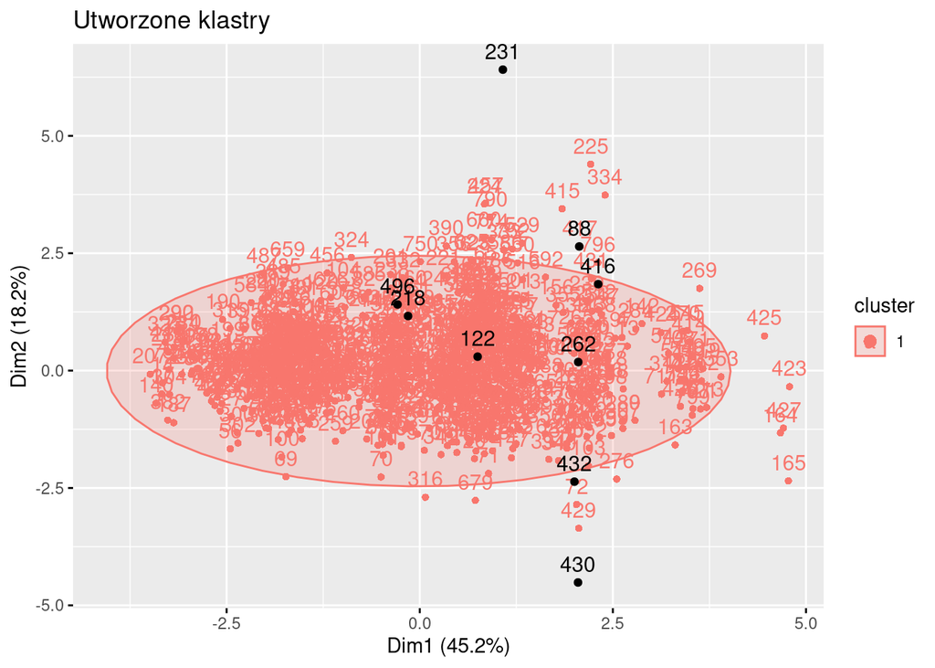

```r
#?fviz_cluster
fviz_cluster(dbscan.out, dataPokScale, main = "Utworzone klastry", ellipse.type = "norm")
```

**3d). Przypisanie poszczególnych rekordów do grup**

```r
dataPokScaleDB <- dataPokScale
dataPokScaleDB$Groupe <- dbscan.out$cluster

head(dataPokScaleDB)
```

|  | HP | Attack | Defense | Sp..Atk | Sp..Def | Speed | Groupe |
| --- | --- | --- | --- | --- | --- | --- | --- |
| 1 | 0.6092888 | 0.5734039 | 0.6109768 | 0.8137637 | 0.8426019 | 0.6061101 | 1 |
| 2 | 0.8123851 | 0.7255314 | 0.7855417 | 1.0015554 | 1.0370485 | 0.8081468 | 1 |
| 3 | 1.0831801 | 0.9595738 | 1.0349200 | 1.2519442 | 1.2963107 | 1.0775290 | 1 |
| 4 | 1.0831801 | 1.1702120 | 1.5336766 | 1.5273719 | 1.5555728 | 1.0775290 | 1 |
| 5 | 0.5280503 | 0.6085102 | 0.5361634 | 0.7511665 | 0.6481553 | 0.8754923 | 1 |
| 6 | 0.7853056 | 0.7489357 | 0.7231971 | 1.0015554 | 0.8426019 | 1.0775290 | 1 |

**3e) Znalezienie charakterystycznych elementów grup**

- klaster 1

```r
summary(dataPokScaleDB %>% filter(Groupe == 1))
```

```
##        HP              Attack           Defense           Sp..Atk
##  Min.   :0.01354   Min.   :0.05851   Min.   :0.06234   Min.   :0.1252
##  1st Qu.:0.67699   1st Qu.:0.64362   1st Qu.:0.62345   1st Qu.:0.6260
##  Median :0.88008   Median :0.87766   Median :0.87282   Median :0.8138
##  Mean   :0.92916   Mean   :0.92697   Mean   :0.91966   Mean   :0.9110
##  3rd Qu.:1.08318   3rd Qu.:1.17021   3rd Qu.:1.12220   3rd Qu.:1.1893
##  Max.   :2.30176   Max.   :2.22340   Max.   :2.86785   Max.   :2.4288
##     Sp..Def           Speed            Groupe
##  Min.   :0.2593   Min.   :0.1347   Min.   :1
##  1st Qu.:0.6482   1st Qu.:0.6061   1st Qu.:1
##  Median :0.9074   Median :0.8755   Median :1
##  Mean   :0.9262   Mean   :0.9206   Mean   :1
##  3rd Qu.:1.1667   3rd Qu.:1.2122   3rd Qu.:1
##  Max.   :2.0741   Max.   :2.1551   Max.   :1
```

Cieżko zidentyfikować cechy szczególne grupy,w przypadku otrzymania w ramach grupowania tylko jednego klastra.

- punkty szumu

```r
summary(dataPokScaleDB %>% filter(Groupe == 0))
```

```
##        HP             Attack           Defense           Sp..Atk
##  Min.   :0.2708   Min.   :0.05851   Min.   :0.06234   Min.   :0.1252
##  1st Qu.:0.6770   1st Qu.:0.11702   1st Qu.:0.24938   1st Qu.:0.4382
##  Median :1.2863   Median :0.58511   Median :0.72320   Median :0.9390
##  Mean   :1.6925   Mean   :0.70603   Mean   :1.01552   Mean   :0.9710
##  3rd Qu.:2.5726   3rd Qu.:0.99468   3rd Qu.:1.24689   3rd Qu.:1.2519
##  Max.   :3.4526   Max.   :2.10638   Max.   :2.86785   Max.   :2.2535
##     Sp..Def           Speed             Groupe
##  Min.   :0.2593   Min.   :0.06735   Min.   :0
##  1st Qu.:1.0370   1st Qu.:0.40407   1st Qu.:0
##  Median :1.1667   Median :0.67346   Median :0
##  Mean   :1.4447   Mean   :0.83508   Mean   :0
##  3rd Qu.:1.7500   3rd Qu.:0.74080   3rd Qu.:0
##  Max.   :2.9815   Max.   :2.42444   Max.   :0
```

Zgodnie z oczekiwaniami wartości punktów szumu, różnią się od tych zgrupowanych w ramach klastra 1. Patrząc na wartości średnie można zauważyć,że są punkty szumu, które mają większe wartości atrybutu HP, Defence oraz Spec.Defence.

**4. Porównanie wyników uzyskanych dwoma metodami grupowania.**

W ramach przeprowadzonych eksperymentów otrzymaliśmy różne wyniki w ramach poszczególnych algorytmów grupowania. Zdecydowanie bardziej obiecujące wyniki otrzymaliśmy w ramach grupowania danych algorytmem kmeans dla których otrzymaliśmy lepsze i sensowniejsze wyniki. Algorytm kmeans podzielił nam zbiór na dwa klastry dla których wartości indeksu Silhouette były większe od zera, a wartości mniejszych od zera było ok. 6%.

Nie zadowolające były wyniki otrzymane w ramach algorytmu DBSCAN dla którego otrzymaliśmy tylko jedną grupę, co w konsekwencji sprowadziło się do braku grupowania. Mimo doboru odpowiednich parametrów eps oraz minPts (i ich kombinacji), nie otrzymano grup dla których liczność byłaby większa niż 5 obserwacji (przy 800 obiektach).